# Cardiovascular disease detection

Tathagata Bardhan

# Importing the dataset

```r
`cardio_train(project)` <- read.csv("C:/Users/user/OneDrive/Desktop/project-baan bapat/cardio_train(project).csv")
data=`cardio_train(project)`
head(data)
```

```
##   id   age gender height weight ap_hi ap_lo cholesterol gluc smoke alco active
## 1  0 18393      2    168     62   110    80           1    1     0    0      1
## 2  1 20228      1    156     85   140    90           3    1     0    0      1
## 3  2 18857      1    165     64   130    70           3    1     0    0      0
## 4  3 17623      2    169     82   150   100           1    1     0    0      1
## 5  4 17474      1    156     56   100    60           1    1     0    0      0
## 6  8 21914      1    151     67   120    80           2    2     0    0      0
##   cardio
## 1      0
## 2      1
## 3      1
## 4      1
## 5      0
## 6      0
```

# Data cleaning

*Eliminating patient ID column*

```r
Mydata=data[,-1]
```

*Null value detection*

```r
sapply(Mydata,function(x) sum(is.na(x)))
```

```
##         age      gender      height      weight       ap_hi       ap_lo
##           0           0           0           0           0           0
## cholesterol        gluc       smoke        alco      active      cardio
##           0           0           0           0           0           0
```

**So there are no null values in the dataset**

```r
head(Mydata)
```

```
##     age gender height weight ap_hi ap_lo cholesterol gluc smoke alco active
## 1 18393      2    168     62   110    80           1    1     0    0      1
## 2 20228      1    156     85   140    90           3    1     0    0      1
## 3 18857      1    165     64   130    70           3    1     0    0      0
## 4 17623      2    169     82   150   100           1    1     0    0      1
## 5 17474      1    156     56   100    60           1    1     0    0      0
## 6 21914      1    151     67   120    80           2    2     0    0      0
##   cardio
## 1      0
## 2      1
## 3      1
## 4      1
## 5      0
## 6      0
```

```r
summary(Mydata)
```

```
##       age            gender         height          weight
##  Min.   :10798   Min.   :1.00   Min.   : 55.0   Min.   : 10.00
##  1st Qu.:17664   1st Qu.:1.00   1st Qu.:159.0   1st Qu.: 65.00
##  Median :19703   Median :1.00   Median :165.0   Median : 72.00
##  Mean   :19469   Mean   :1.35   Mean   :164.4   Mean   : 74.21
##  3rd Qu.:21327   3rd Qu.:2.00   3rd Qu.:170.0   3rd Qu.: 82.00
##  Max.   :23713   Max.   :2.00   Max.   :250.0   Max.   :200.00
##      ap_hi             ap_lo           cholesterol         gluc
##  Min.   : -150.0   Min.   :  -70.00   Min.   :1.000   Min.   :1.000
##  1st Qu.:  120.0   1st Qu.:   80.00   1st Qu.:1.000   1st Qu.:1.000
##  Median :  120.0   Median :   80.00   Median :1.000   Median :1.000
##  Mean   :  128.8   Mean   :   96.63   Mean   :1.367   Mean   :1.226
##  3rd Qu.:  140.0   3rd Qu.:   90.00   3rd Qu.:2.000   3rd Qu.:1.000
##  Max.   :16020.0   Max.   :11000.00   Max.   :3.000   Max.   :3.000
##      smoke              alco             active           cardio
##  Min.   :0.00000   Min.   :0.00000   Min.   :0.0000   Min.   :0.0000
##  1st Qu.:0.00000   1st Qu.:0.00000   1st Qu.:1.0000   1st Qu.:0.0000
##  Median :0.00000   Median :0.00000   Median :1.0000   Median :0.0000
##  Mean   :0.08813   Mean   :0.05377   Mean   :0.8037   Mean   :0.4997
##  3rd Qu.:0.00000   3rd Qu.:0.00000   3rd Qu.:1.0000   3rd Qu.:1.0000
##  Max.   :1.00000   Max.   :1.00000   Max.   :1.0000   Max.   :1.0000
```

```r
dim(Mydata)
```

```
## [1] 70000    12
```

*Identifying duplicate rows*

```r
df=unique(Mydata)
dim(df)
```

```
## [1] 69976    12
```

**So, there were 24 duplicate rows in the dataset**

*Outliers detection*

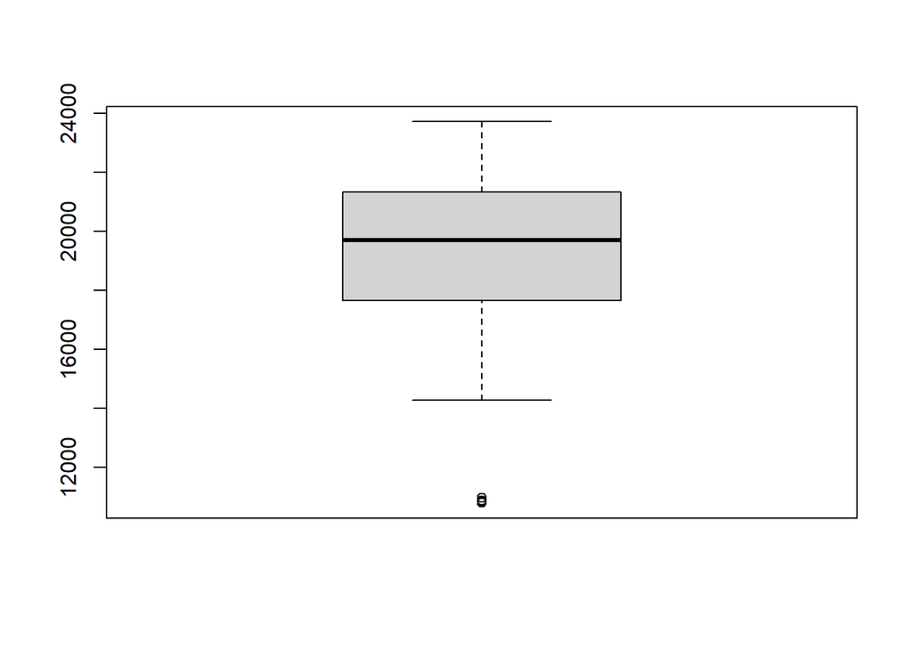

```r
a=boxplot(df$age)$out
```

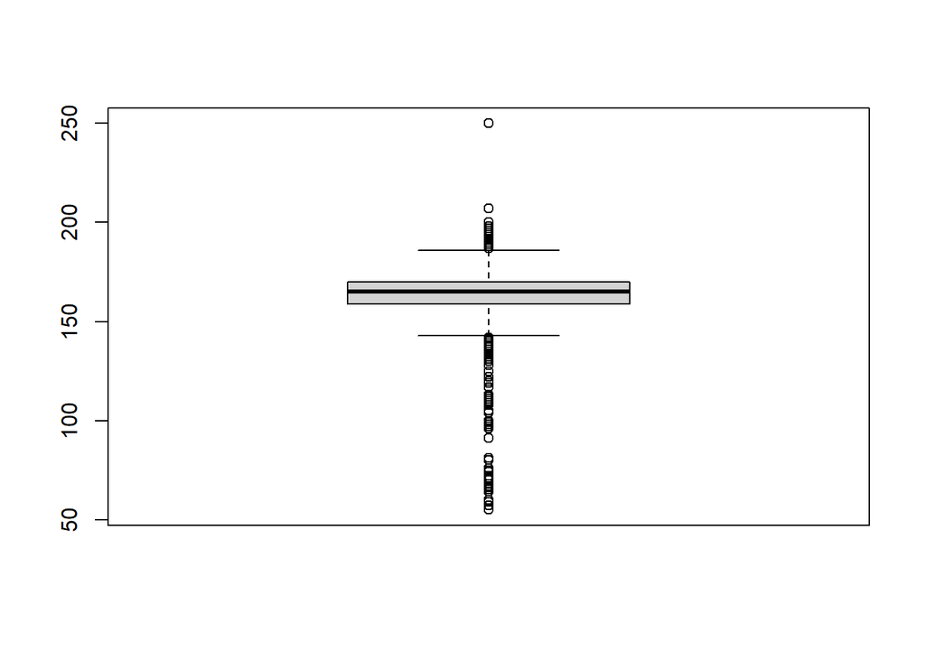

```r
b=boxplot(df$height)$out
```

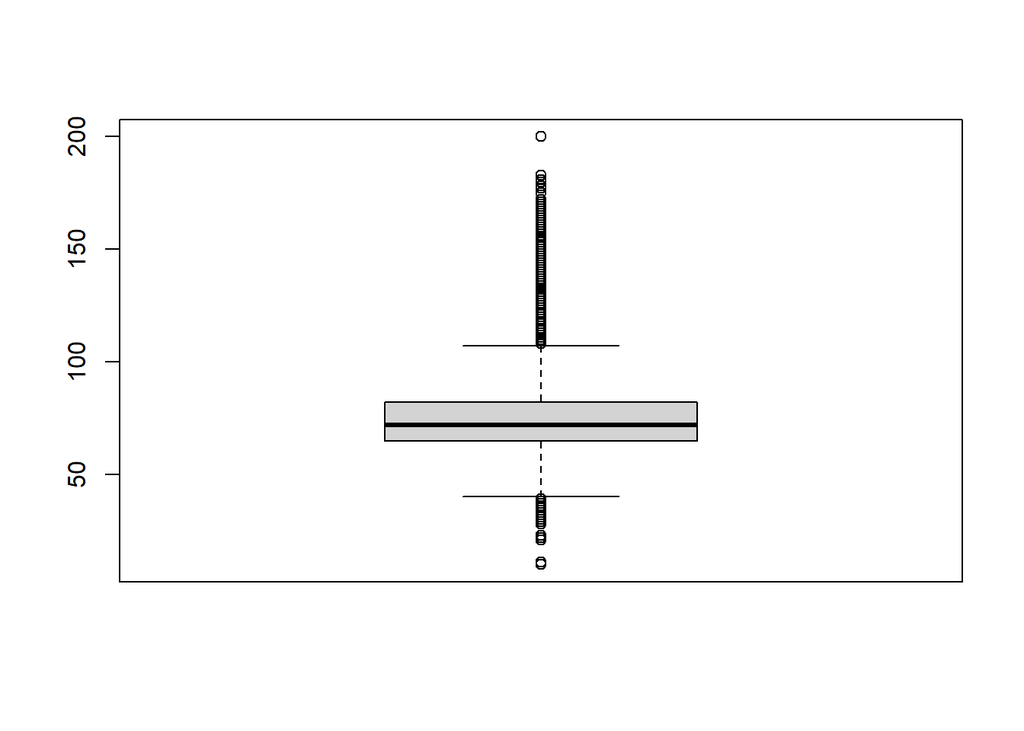

```r
c=boxplot(df$weight)$out
```

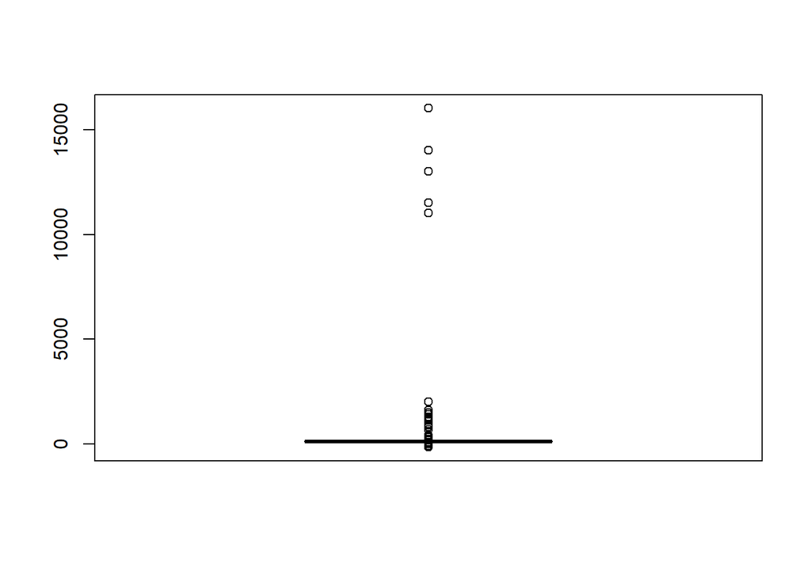

```r
d=boxplot(df$ap_hi)$out
```

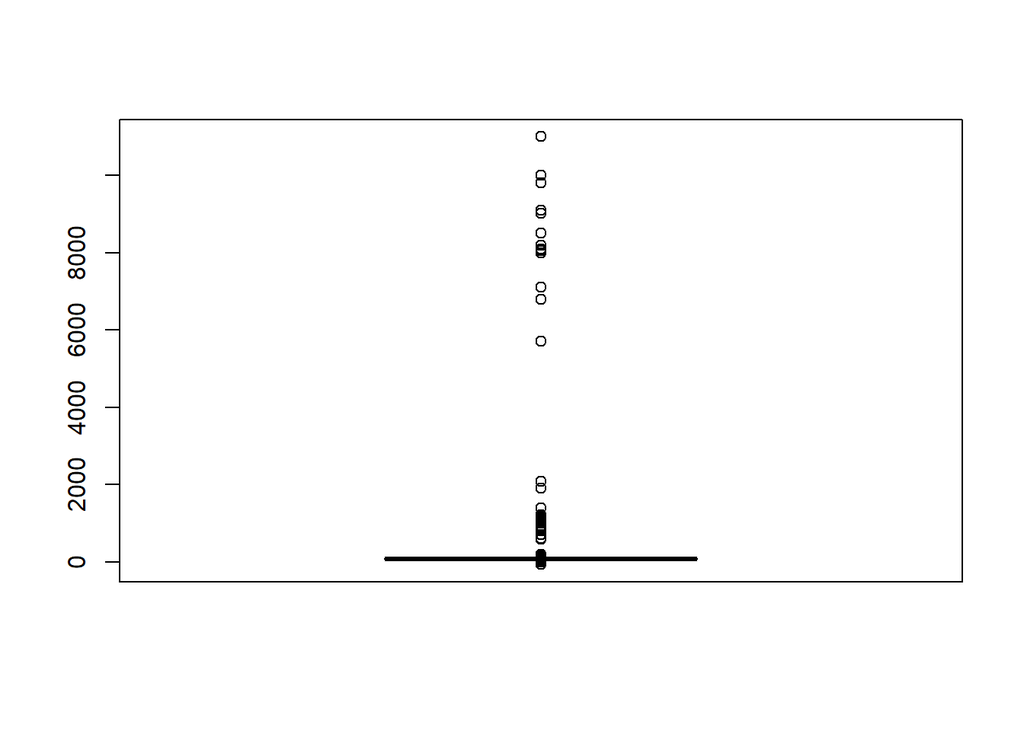

```r
e=boxplot(df$ap_lo)$out
```

**So, there are 4 outliers in the variable ‘Age’, 519 outliers in variable ‘Height’, 1819 outliers in variable ‘Weight’, 1435 and 4632 outliers in variables ‘ap_hi’ and ‘ap_lo’ respectively.** **These are to be treated.**

```r
x=c()
for(i in 1:length(a)){
  x=c(x,which(df$age==a[i]))
}
y=c()
for(i in 1:length(b)){
  y=c(y,which(df$height==b[i]))
}
z=c()
for(i in 1:length(c)){
  z=c(z,which(df$weight==c[i]))
}
p=c()
for(i in 1:length(d)){
  p=c(p,which(df$ap_hi==d[i]))
}
q=c()
for(i in 1:length(e)){
  q=c(q,which(df$ap_lo==e[i]))
}
```

```r
data_cardio=df
data_cardio$age[x]=min(data_cardio$age[-x])

data_cardio$height[data_cardio$height>(quantile(data_cardio$height,0.75)+(1.5*IQR(data_cardio$height)))]=max(data_cardio$height[-y])
data_cardio$height[data_cardio$height<(quantile(data_cardio$height,0.25)-(1.5*IQR(data_cardio$height)))]=min(data_cardio$height[-y])

data_cardio$weight[data_cardio$weight>(quantile(data_cardio$weight,0.75)+(1.5*IQR(data_cardio$weight)))]=max(data_cardio$weight[-z])
data_cardio$weight[data_cardio$weight<(quantile(data_cardio$weight,0.25)-(1.5*IQR(data_cardio$weight)))]=min(data_cardio$weight[-z])

data_cardio$ap_hi[data_cardio$ap_hi>(quantile(data_cardio$ap_hi,0.75)+(1.5*IQR(data_cardio$ap_hi)))]=max(data_cardio$ap_hi[-p])
data_cardio$ap_hi[data_cardio$ap_hi<(quantile(data_cardio$ap_hi,0.25)-(1.5*IQR(data_cardio$ap_hi)))]=min(data_cardio$ap_hi[-p])

data_cardio$ap_lo[data_cardio$ap_lo>(quantile(data_cardio$ap_lo,0.75)+(1.5*IQR(data_cardio$ap_lo)))]=max(data_cardio$ap_lo[-q])
data_cardio$ap_lo[data_cardio$ap_lo<(quantile(data_cardio$ap_lo,0.25)-(1.5*IQR(data_cardio$ap_lo)))]=min(data_cardio$ap_lo[-q])
```

*For removal of outliers, for each variable, the values greater than Q3+1.5IQR are replaced by the maximum of the values other than the outliers and the values less than Q1-1.5IQR are replaced by the minimum of the values other than the outliers.*

**Verification**

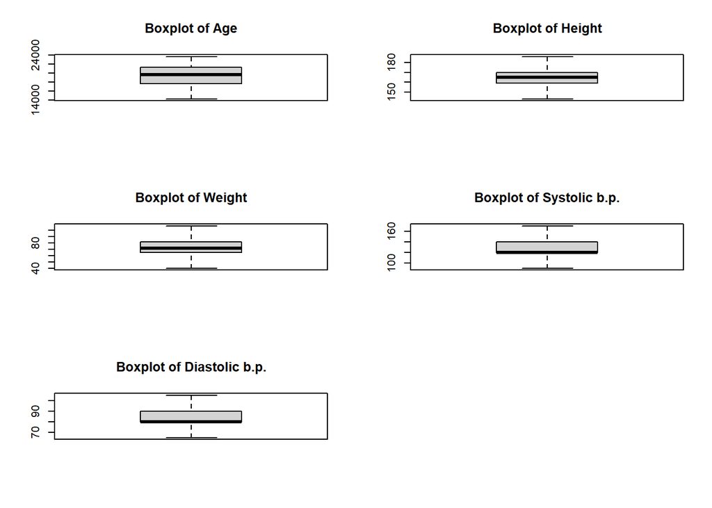

```r
par(mfrow=c(3,2))
boxplot(data_cardio$age,main="Boxplot of Age")
boxplot(data_cardio$height,main="Boxplot of Height")
boxplot(data_cardio$weight,main="Boxplot of Weight")
boxplot(data_cardio$ap_hi,main="Boxplot of Systolic b.p.")
boxplot(data_cardio$ap_lo,main="Boxplot of Diastolic b.p.")
```

**We can ensure that there are no more outliers in the dataset**

```r
dim(data_cardio)
```

```
## [1] 69976    12
```

**Thus we have our cleaned dataset ‘data_cardio’ which is free from missing values, duplicate values & outliers**

# Univariate Analysis

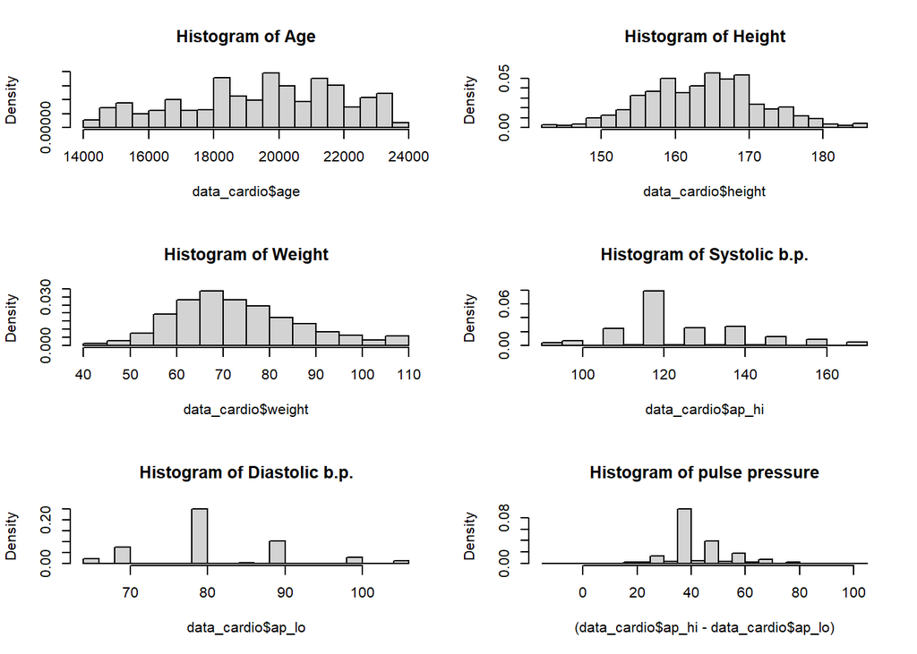

```r
par(mfrow=c(3,2))
hist(data_cardio$age,main="Histogram of Age",prob=TRUE)
hist(data_cardio$height,main="Histogram of Height",prob=TRUE)
hist(data_cardio$weight,main="Histogram of Weight",prob=TRUE)
hist(data_cardio$ap_hi,main="Histogram of Systolic b.p.",prob=TRUE)
hist(data_cardio$ap_lo,main="Histogram of Diastolic b.p.",prob=TRUE)
hist((data_cardio$ap_hi-data_cardio$ap_lo),main="Histogram of pulse pressure",prob=TRUE)
```

**Height and weight are more or less symmetrically distributed and age is slightly negatively skewed**

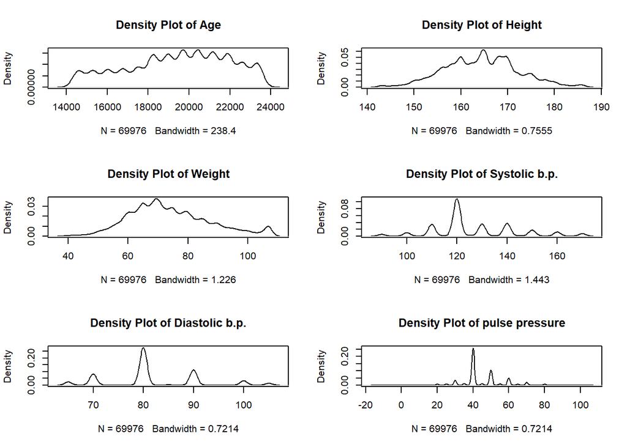

```r
par(mfrow=c(3,2))
plot(density(data_cardio$age),main="Density Plot of Age")
plot(density(data_cardio$height),main="Density Plot of Height")
plot(density(data_cardio$weight),main="Density Plot of Weight")
plot(density(data_cardio$ap_hi),main="Density Plot of Systolic b.p.")
plot(density(data_cardio$ap_lo),main="Density Plot of Diastolic b.p.")
plot(density(data_cardio$ap_hi-data_cardio$ap_lo),main="Density Plot of pulse pressure")
```

**Most of the patients are in the age of 18000 to 22000 days, are of height 160 to 170 cm, weight 60 to 80 kg & most of the patients have systolic bp 120 and diastolic bp 80 i.e. b.p. is in normal range**

# Bivariate Analysis

```r
summary(data_cardio)
```

```
##       age            gender         height          weight
##  Min.   :14275   Min.   :1.00   Min.   :143.0   Min.   : 40.00
##  1st Qu.:17664   1st Qu.:1.00   1st Qu.:159.0   1st Qu.: 65.00
##  Median :19703   Median :1.00   Median :165.0   Median : 72.00
##  Mean   :19469   Mean   :1.35   Mean   :164.4   Mean   : 73.92
##  3rd Qu.:21327   3rd Qu.:2.00   3rd Qu.:170.0   3rd Qu.: 82.00
##  Max.   :23713   Max.   :2.00   Max.   :186.0   Max.   :107.00
##      ap_hi           ap_lo         cholesterol         gluc
##  Min.   : 90.0   Min.   : 65.00   Min.   :1.000   Min.   :1.000
##  1st Qu.:120.0   1st Qu.: 80.00   1st Qu.:1.000   1st Qu.:1.000
##  Median :120.0   Median : 80.00   Median :1.000   Median :1.000
##  Mean   :126.7   Mean   : 81.78   Mean   :1.367   Mean   :1.227
##  3rd Qu.:140.0   3rd Qu.: 90.00   3rd Qu.:2.000   3rd Qu.:1.000
##  Max.   :170.0   Max.   :105.00   Max.   :3.000   Max.   :3.000
##      smoke              alco             active           cardio
##  Min.   :0.00000   Min.   :0.00000   Min.   :0.0000   Min.   :0.0000
##  1st Qu.:0.00000   1st Qu.:0.00000   1st Qu.:1.0000   1st Qu.:0.0000
##  Median :0.00000   Median :0.00000   Median :1.0000   Median :0.0000
##  Mean   :0.08816   Mean   :0.05379   Mean   :0.8037   Mean   :0.4998
##  3rd Qu.:0.00000   3rd Qu.:0.00000   3rd Qu.:1.0000   3rd Qu.:1.0000
##  Max.   :1.00000   Max.   :1.00000   Max.   :1.0000   Max.   :1.0000
```

```r
round((cor(data_cardio[,-c(12)])),4)
```

```
##                 age  gender  height  weight  ap_hi  ap_lo cholesterol    gluc
## age          1.0000 -0.0228 -0.0866  0.0597 0.2093 0.1557      0.1544  0.0987
## gender      -0.0228  1.0000  0.5223  0.1630 0.0617 0.0670     -0.0359 -0.0206
## height      -0.0866  0.5223  1.0000  0.3169 0.0166 0.0305     -0.0547 -0.0207
## weight       0.0597  0.1630  0.3169  1.0000 0.2741 0.2589      0.1438  0.1056
## ap_hi        0.2093  0.0617  0.0166  0.2741 1.0000 0.7257      0.1973  0.0926
## ap_lo        0.1557  0.0670  0.0305  0.2589 0.7257 1.0000      0.1660  0.0757
## cholesterol  0.1544 -0.0359 -0.0547  0.1438 0.1973 0.1660      1.0000  0.4515
## gluc         0.0987 -0.0206 -0.0207  0.1056 0.0926 0.0757      0.4515  1.0000
## smoke       -0.0477  0.3381  0.1963  0.0687 0.0272 0.0270      0.0103 -0.0048
## alco        -0.0298  0.1710  0.0980  0.0682 0.0324 0.0407      0.0357  0.0112
## active      -0.0099  0.0059 -0.0082 -0.0174 0.0021 0.0016      0.0099 -0.0068
##               smoke    alco  active
## age         -0.0477 -0.0298 -0.0099
## gender       0.3381  0.1710  0.0059
## height       0.1963  0.0980 -0.0082
## weight       0.0687  0.0682 -0.0174
## ap_hi        0.0272  0.0324  0.0021
## ap_lo        0.0270  0.0407  0.0016
## cholesterol  0.0103  0.0357  0.0099
## gluc        -0.0048  0.0112 -0.0068
## smoke        1.0000  0.3401  0.0259
## alco         0.3401  1.0000  0.0255
## active       0.0259  0.0255  1.0000
```

```r
cor.test(data_cardio$ap_hi,data_cardio$ap_lo)$p.value
```

```
## [1] 0
```

**So there is significant correlation between Systolic and Diastolic b.p.**

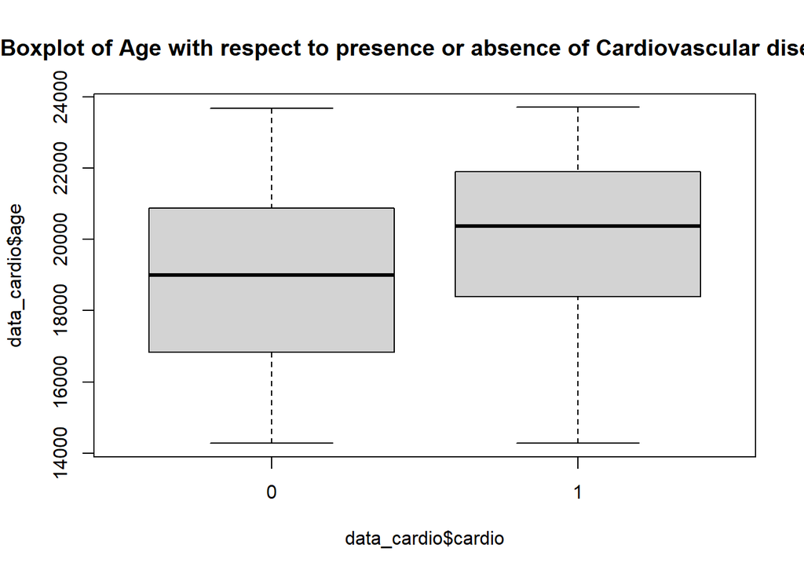

```r
par(mfrow=c(1,1))
boxplot(data_cardio$age~data_cardio$cardio,main="Boxplot of Age with respect to presence or absence of Cardiovascular disease")
```

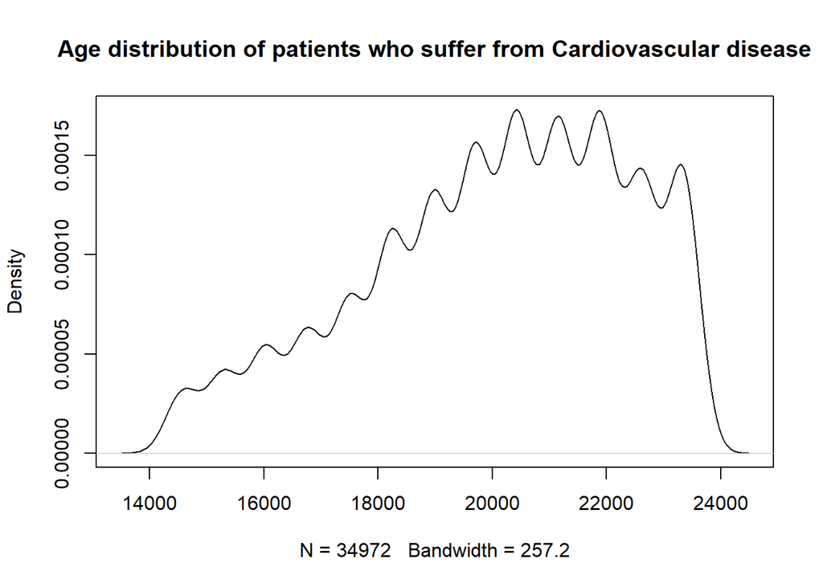

```r
plot(density(data_cardio$age[data_cardio$cardio==1]),main="Age distribution of patients who suffer from Cardiovascular disease")
```

**Thus on an average, people older in age suffer more heart disease than those who are younger. More precisely patients having age between 20,000-22,000 days i.e. between 55 to 60 years, suffer mostly with cardiovascular disease**

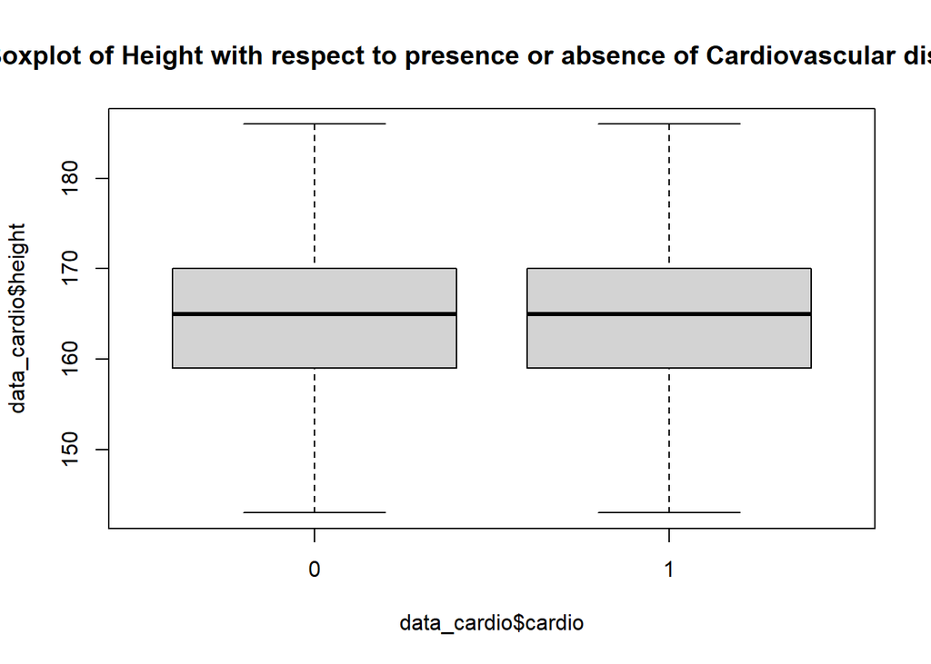

```r
par(mfrow=c(1,1))
boxplot(data_cardio$height~data_cardio$cardio,main="Boxplot of Height with respect to presence or absence of Cardiovascular disease")
```

**Thus on an average, people who don’t suffer from Cardiovascular disease have same height with those who suffer from the disease. Thus height of a person doesn’t play major role in detection of the disease**

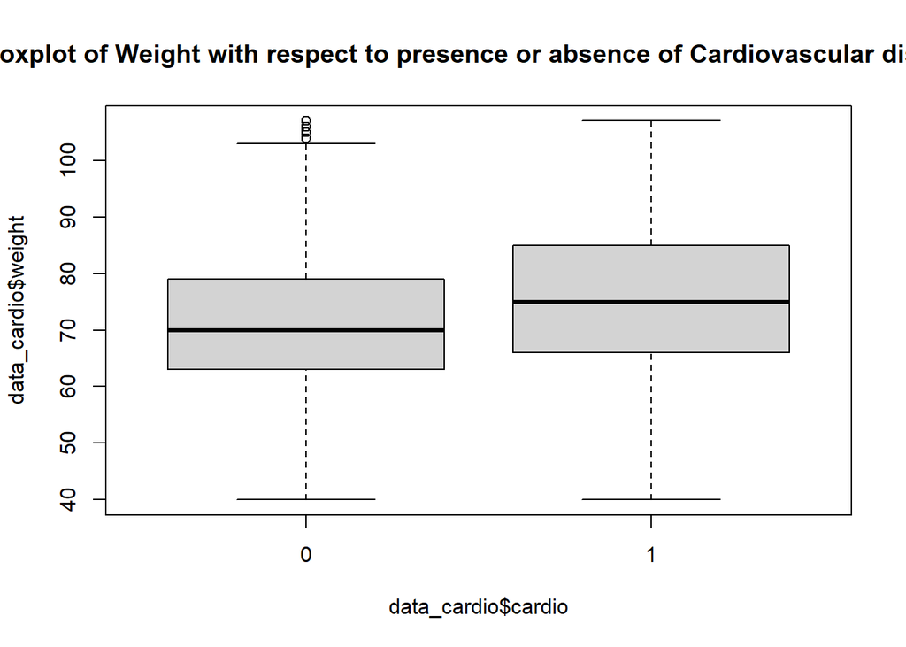

```r
par(mfrow=c(1,1))
boxplot(data_cardio$weight~data_cardio$cardio,main="Boxplot of Weight with respect to presence or absence of Cardiovascular disease")
```

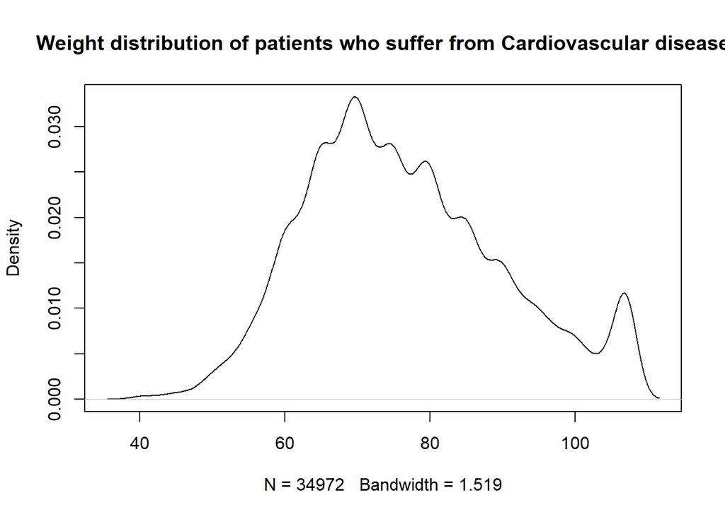

```r
plot(density(data_cardio$weight[data_cardio$cardio==1]),main="Weight distribution of patients who suffer from Cardiovascular disease")
```

**Thus, on an average, people who have suffered from Cardiovascular disease have more weight than those who didn’t, infact it is mostly occuring for patients whose weights are within 65-75 kgs**